# VRT Examples USGS

Mike Johnson

3DEP is the national elevation dataset in the US. It provides a wealth of information and is critical to many environmental applications. This document trys to outline the advantages of the 3DEP VRT files.

# Context: *Fort Collins, Colorado*

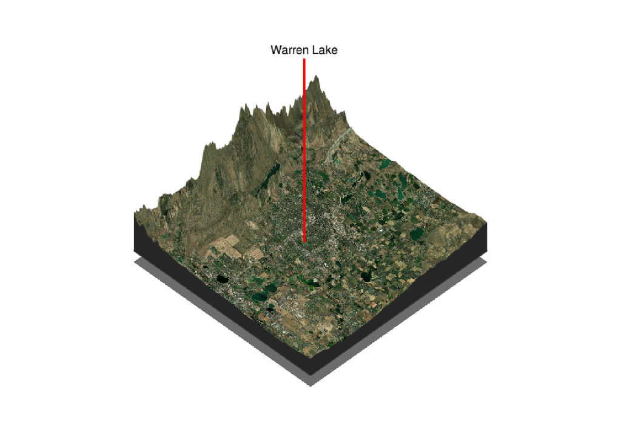

# 1. Flexabilty

The VRT resources are not only easy to use, but also provide extreme flexibility in meeting applications goals. The range in possible ways to “use” the data span the gambit.

Here we provide three examples that increase in complexity and utility. The key is that on the “easy” side, users can very simply get the data they want from the best available 3DEP treating a URL as if it was a local file in any programming language! On the more complex side users can control the resolution, projection, extent, and resampling of the data with minimal effort.

[figure not shown]

## Simple Use

The most simple way to access this data is to define an resource (URL) and “open” it. Below we see that entire 3DEP product for res-1 is accessible, *but*, we havent yet pulled any data yet to process.

This will allow us to work on the spatial metadata without yet touching the data.

```r
url = "/vsicurl/https://prd-tnm.s3.amazonaws.com/StagedProducts/Elevation/1/TIFF/USGS_Seamless_DEM_1.vrt"
(elev = rast(url))
```

```
## class       : SpatRaster
## dimensions  : 356412, 1206012, 1  (nrow, ncol, nlyr)
## resolution  : 0.0002777778, 0.0002777778  (x, y)
## extent      : -171.0017, 164.0017, -15.00167, 84.00167  (xmin, xmax, ymin, ymax)
## coord. ref. : lon/lat NAD83 (EPSG:4269)
## source      : USGS_Seamless_DEM_1.vrt
## name        : USGS_Seamless_DEM_1
## min value   :            -8.43504
## max value   :            3646.806
```

Say we want just *some* of that data for an area - like Fort Collins 😄. As long as we know the area, we can extract just that component very quickly:

```r
AOI = AOI::aoi_get("Fort Collins")

ss = system.time({
  #Project the AOI to the CRS of 3DEP, and extract the values!
  (data = crop(elev, project(vect(AOI), crs(elev))))
})
```

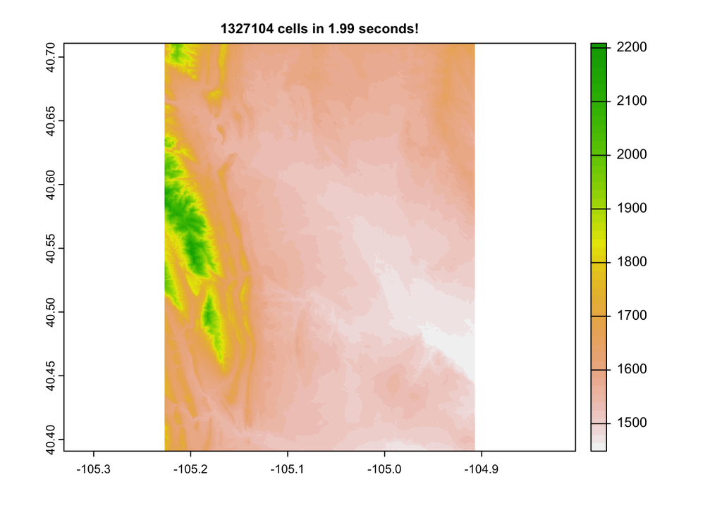

With this VRT we are getting a transfer speed of ~ 6.6688643^{5} values/second and have an object that is ready to work with.

Equally improtant, this is the identical process a user would employ if they had to download the enture seamless product to disk (e.g. NLCD!). In other words the “cloud” aspects of the workflow are abstracted away without requiring the USGS to create a service, or for a single seamless file to ever be needed.

### Programatic use

The process of open/align/extract by area are so common that wrapping it up in a programmatic workflow “makes sense”. We did so over in `opendap.catalog`.

```r
library(opendap.catalog)
(data = dap(url, AOI = AOI))
```

```
## class       : SpatRaster
## dimensions  : 1152, 1152, 1  (nrow, ncol, nlyr)
## resolution  : 0.0002777778, 0.0002777778  (x, y)
## extent      : -105.2269, -104.9069, 40.39083, 40.71083  (xmin, xmax, ymin, ymax)
## coord. ref. : lon/lat NAD83 (EPSG:4269)
## source      : memory
## name        : USGS_Seamless_DEM_1
## min value   :             1448.79
## max value   :             2210.44
```

The cool thing about “programmatic” access is that any VRT can be passed to the same signiture to get local data from remote, large datasets. Here, the same call can be used to instead get the 1/3 arc second 3DEP product.

```r
(dap(URL = "/vsicurl/https://prd-tnm.s3.amazonaws.com/StagedProducts/Elevation/13/TIFF/USGS_Seamless_DEM_13.vrt",
     AOI = AOI))
```

```
## class       : SpatRaster
## dimensions  : 3456, 3456, 1  (nrow, ncol, nlyr)
## resolution  : 9.259259e-05, 9.259259e-05  (x, y)
## extent      : -105.2269, -104.9069, 40.39083, 40.71083  (xmin, xmax, ymin, ymax)
## coord. ref. : lon/lat NAD83 (EPSG:4269)
## source      : memory
## name        : USGS_Seamless_DEM_13
## min value   :              1448.79
## max value   :             2210.755
```

Same extent but more data 👩‍🎨

## Target Grids

```r
cat = search('polaris sand mean 0_5')
cat$URL
```

```
## [1] "/vsicurl/http://hydrology.cee.duke.edu/POLARIS/PROPERTIES/v1.0/vrt/sand_mean_0_5.vrt"
```

```r
(sand = dap(catolog = cat, AOI = AOI))
```

```
## class       : SpatRaster
## dimensions  : 1152, 1152, 1  (nrow, ncol, nlyr)
## resolution  : 0.0002777778, 0.0002777778  (x, y)
## extent      : -105.2269, -104.9069, 40.39083, 40.71083  (xmin, xmax, ymin, ymax)
## coord. ref. : lon/lat WGS 84 (EPSG:4326)
## source      : memory
## name        : sand_mean_0_5
## min value   :      13.56037
## max value   :      88.37305
```

Same extent

```r
target = sand[[1]]

v <- vapour_warp_raster_dbl(url,
                            resample  = "bilinear",
                            extent = as.vector(ext(target)),
                            dimension = dim(target)[1:2],
                            projection = crs(target))

r = rast(matrix(v, dim(target)[1], byrow = T),
                extent = ext(target),
                crs  = crs(target))

names(r) = "elev"

(d = c(sand, r))
```

```
## class       : SpatRaster
## dimensions  : 1152, 1152, 2  (nrow, ncol, nlyr)
## resolution  : 0.0002777778, 0.0002777778  (x, y)
## extent      : -105.2269, -104.9069, 40.39083, 40.71083  (xmin, xmax, ymin, ymax)
## coord. ref. : lon/lat WGS 84 (EPSG:4326)
## sources     : memory
##               memory
## names       : sand_mean_0_5,       elev
## min values  :      13.56037, 1448.79004
## max values  :      88.37305, 2210.43652
```

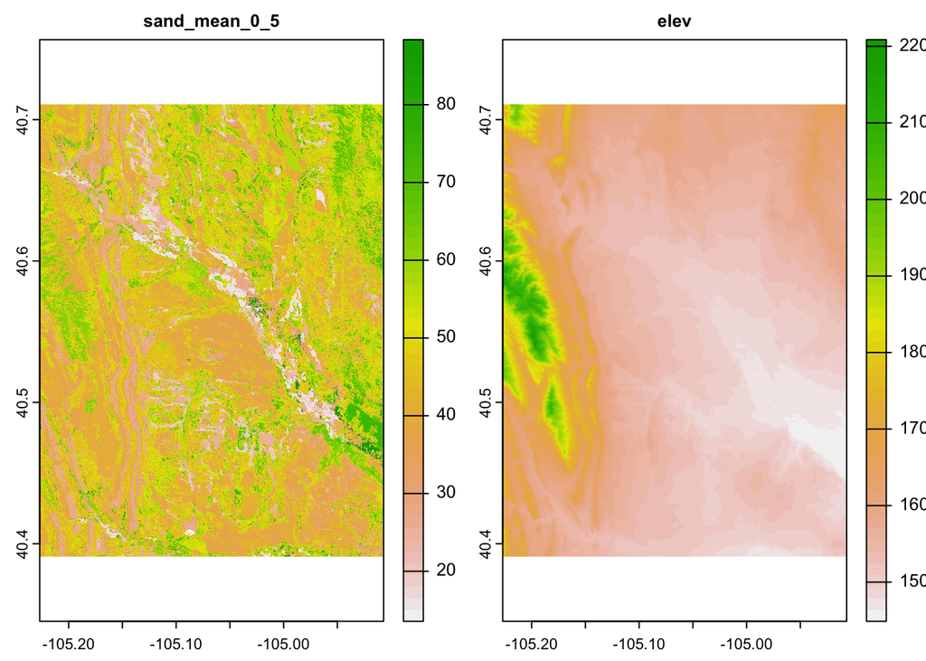

```r
plot(d)
```

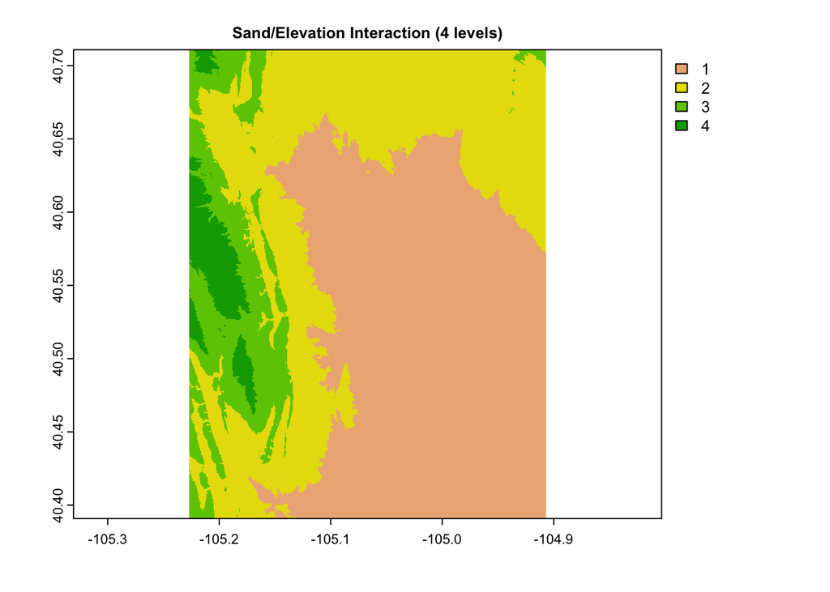

```r
df <- as.data.frame(d, na.rm = FALSE)
df[is.na(df)] <- 0

cluster <- d[[1]]
names(cluster)  = "class"
cluster[] <-  kmeans(df, 4)$cluster

plot(cluster, main = "Sand/Elevation Interaction (4 levels)")
```